# Jh_eda_file

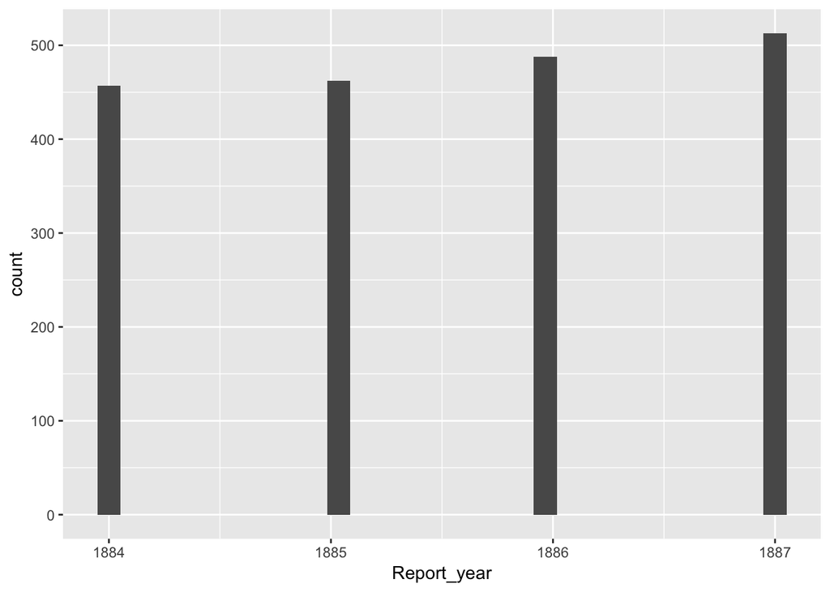

```r
ggplot(abcfm_missionaries, aes(Report_year)) + geom_histogram()
```

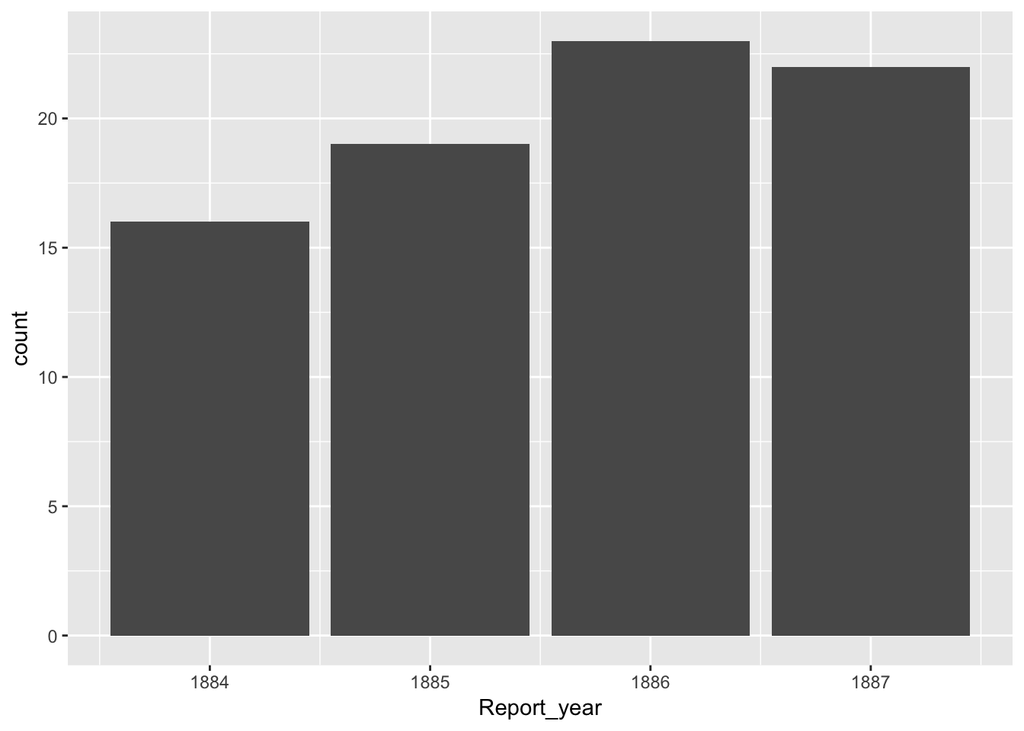

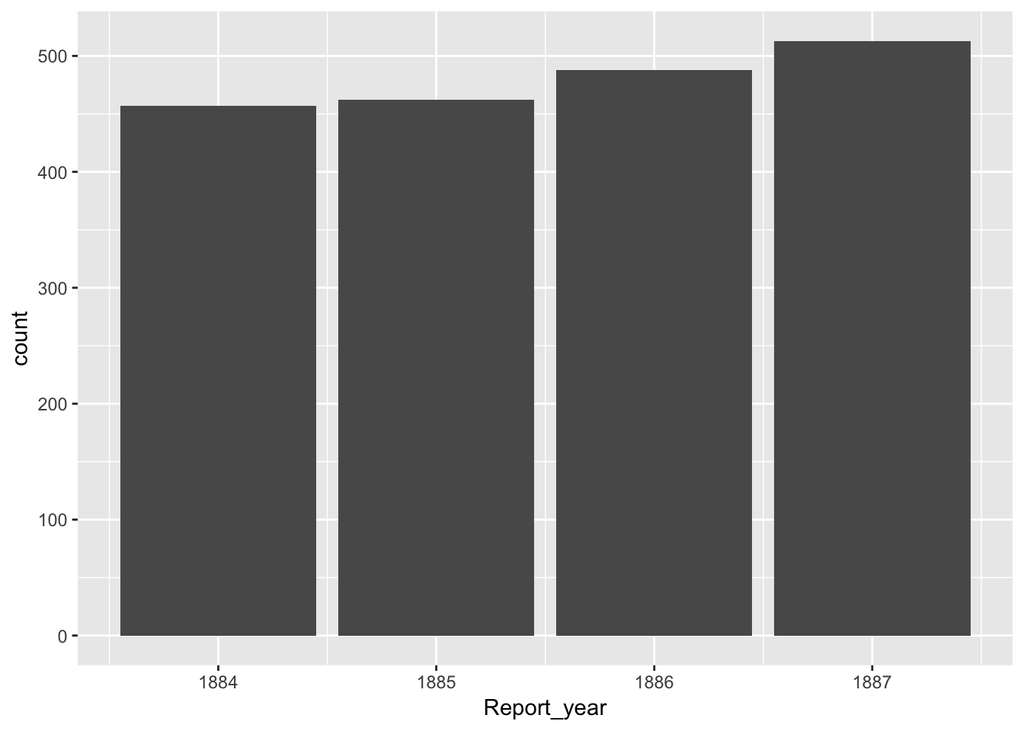

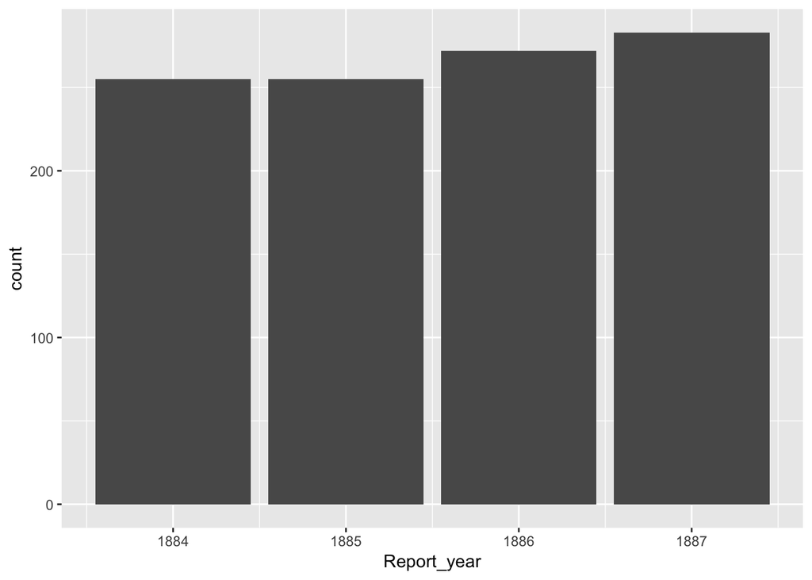

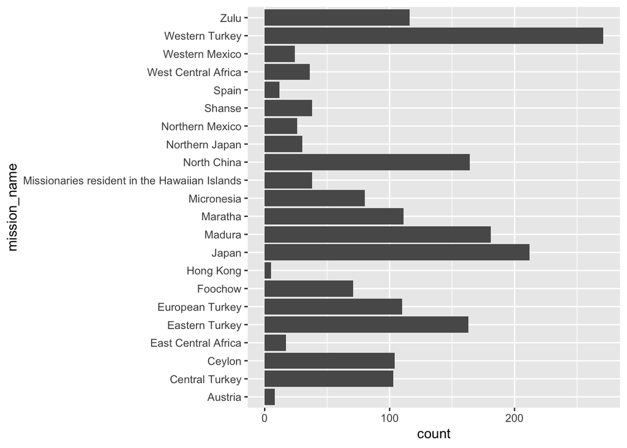

```r
#The histogram above only displays that the number of missionaries increased over this four year period.
```

# The above plot shows the total number of persons associated with each mission from 1884-1887. An interesting feature of the above graphs is that the total number of missionaries associated with Turkey far exceeded the number of missionaries associated with any other geographic region.

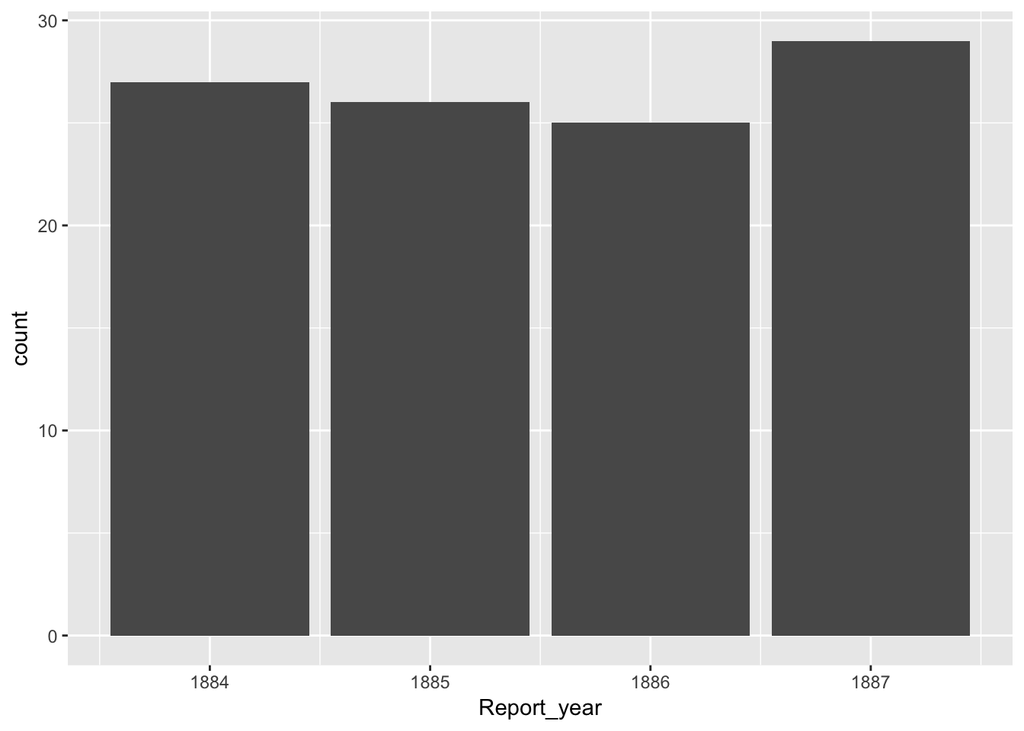

```r
ggplot(abcfm_missionaries_native, aes(Report_year))+ geom_bar()
```

# The plot above shows the number of native pastors named in ABCFM annual reports.

# Overall, the data has a few major problems. It is not tidy enough and I need to add gender as a variable. It is also tricky to plot data for each specific mission for each year, which is a problem that will need to be resolved before any further analysis can move forward. The lack of continus variables aside from year also presents a problem and it may be beneficial to include total numbers of mission congregations in a separate table to join to this one. I will also need a geographic coordinate data frame.

[output not shown]